# Project: Investigate A Dataset - TMDB Data Analysis

- Introduction
- Data Wrangling
- Exploratory Data Analysis
- Conclusions

## Introduction

> In this project, I will be asking questions to see if certain aspects of movies can help us predict if a movie will be a success or not. For this, I will be analyzing the TMDB movie dataset from Kaggel, which contains data on over 10,000 films.

```python
# Import the libraries
import numpy as np
import pandas as pd
import matplotlib.pyplot as plt
import seaborn as sns
%matplotlib inline
```

```python
# set grid style
sns.set_style('darkgrid')
```

```python
# Import data
df = pd.read_csv('tmdb-movies.csv')
```

## Data Wrangling

### General Properties

```python
# View of the first 5 rows
df.head()
```

|  | id | imdb_id | popularity | budget | revenue | original_title | cast | homepage | director | tagline | ... | overview | runtime | genres | production_companies | release_date | vote_count | vote_average | release_year | budget_adj | revenue_adj |
| --- | --- | --- | --- | --- | --- | --- | --- | --- | --- | --- | --- | --- | --- | --- | --- | --- | --- | --- | --- | --- | --- |
| 0 | 135397 | tt0369610 | 32.985763 | 150000000 | 1513528810 | Jurassic World | Chris Pratt\|Bryce Dallas Howard\|Irrfan Khan\|Vi... | http://www.jurassicworld.com/ | Colin Trevorrow | The park is open. | ... | Twenty-two years after the events of Jurassic ... | 124 | Action\|Adventure\|Science Fiction\|Thriller | Universal Studios\|Amblin Entertainment\|Legenda... | 6/9/15 | 5562 | 6.5 | 2015 | 1.379999e+08 | 1.392446e+09 |
| 1 | 76341 | tt1392190 | 28.419936 | 150000000 | 378436354 | Mad Max: Fury Road | Tom Hardy\|Charlize Theron\|Hugh Keays-Byrne\|Nic... | http://www.madmaxmovie.com/ | George Miller | What a Lovely Day. | ... | An apocalyptic story set in the furthest reach... | 120 | Action\|Adventure\|Science Fiction\|Thriller | Village Roadshow Pictures\|Kennedy Miller Produ... | 5/13/15 | 6185 | 7.1 | 2015 | 1.379999e+08 | 3.481613e+08 |
| 2 | 262500 | tt2908446 | 13.112507 | 110000000 | 295238201 | Insurgent | Shailene Woodley\|Theo James\|Kate Winslet\|Ansel... | http://www.thedivergentseries.movie/#insurgent | Robert Schwentke | One Choice Can Destroy You | ... | Beatrice Prior must confront her inner demons ... | 119 | Adventure\|Science Fiction\|Thriller | Summit Entertainment\|Mandeville Films\|Red Wago... | 3/18/15 | 2480 | 6.3 | 2015 | 1.012000e+08 | 2.716190e+08 |
| 3 | 140607 | tt2488496 | 11.173104 | 200000000 | 2068178225 | Star Wars: The Force Awakens | Harrison Ford\|Mark Hamill\|Carrie Fisher\|Adam D... | http://www.starwars.com/films/star-wars-episod... | J.J. Abrams | Every generation has a story. | ... | Thirty years after defeating the Galactic Empi... | 136 | Action\|Adventure\|Science Fiction\|Fantasy | Lucasfilm\|Truenorth Productions\|Bad Robot | 12/15/15 | 5292 | 7.5 | 2015 | 1.839999e+08 | 1.902723e+09 |
| 4 | 168259 | tt2820852 | 9.335014 | 190000000 | 1506249360 | Furious 7 | Vin Diesel\|Paul Walker\|Jason Statham\|Michelle ... | http://www.furious7.com/ | James Wan | Vengeance Hits Home | ... | Deckard Shaw seeks revenge against Dominic Tor... | 137 | Action\|Crime\|Thriller | Universal Pictures\|Original Film\|Media Rights ... | 4/1/15 | 2947 | 7.3 | 2015 | 1.747999e+08 | 1.385749e+09 |

5 rows × 21 columns

```python
# Shows the dimentions of the dataframe
df.shape
```

```
(10866, 21)
```

```python
# Summary of the dataframe
df.info()
```

```
<class 'pandas.core.frame.DataFrame'>
RangeIndex: 10866 entries, 0 to 10865
Data columns (total 21 columns):
 #   Column                Non-Null Count  Dtype
---  ------                --------------  -----
 0   id                    10866 non-null  int64
 1   imdb_id               10856 non-null  object
 2   popularity            10866 non-null  float64
 3   budget                10866 non-null  int64
 4   revenue               10866 non-null  int64
 5   original_title        10866 non-null  object
 6   cast                  10790 non-null  object
 7   homepage              2936 non-null   object
 8   director              10822 non-null  object
 9   tagline               8042 non-null   object
 10  keywords              9373 non-null   object
 11  overview              10862 non-null  object
 12  runtime               10866 non-null  int64
 13  genres                10843 non-null  object
 14  production_companies  9836 non-null   object
 15  release_date          10866 non-null  object
 16  vote_count            10866 non-null  int64
 17  vote_average          10866 non-null  float64
 18  release_year          10866 non-null  int64
 19  budget_adj            10866 non-null  float64
 20  revenue_adj           10866 non-null  float64
dtypes: float64(4), int64(6), object(11)
memory usage: 1.7+ MB
```

```python
# Overview of statistics
df.describe()
```

|  | id | popularity | budget | revenue | runtime | vote_count | vote_average | release_year | budget_adj | revenue_adj |
| --- | --- | --- | --- | --- | --- | --- | --- | --- | --- | --- |
| count | 10866.000000 | 10866.000000 | 1.086600e+04 | 1.086600e+04 | 10866.000000 | 10866.000000 | 10866.000000 | 10866.000000 | 1.086600e+04 | 1.086600e+04 |
| mean | 66064.177434 | 0.646441 | 1.462570e+07 | 3.982332e+07 | 102.070863 | 217.389748 | 5.974922 | 2001.322658 | 1.755104e+07 | 5.136436e+07 |
| std | 92130.136561 | 1.000185 | 3.091321e+07 | 1.170035e+08 | 31.381405 | 575.619058 | 0.935142 | 12.812941 | 3.430616e+07 | 1.446325e+08 |
| min | 5.000000 | 0.000065 | 0.000000e+00 | 0.000000e+00 | 0.000000 | 10.000000 | 1.500000 | 1960.000000 | 0.000000e+00 | 0.000000e+00 |
| 25% | 10596.250000 | 0.207583 | 0.000000e+00 | 0.000000e+00 | 90.000000 | 17.000000 | 5.400000 | 1995.000000 | 0.000000e+00 | 0.000000e+00 |
| 50% | 20669.000000 | 0.383856 | 0.000000e+00 | 0.000000e+00 | 99.000000 | 38.000000 | 6.000000 | 2006.000000 | 0.000000e+00 | 0.000000e+00 |
| 75% | 75610.000000 | 0.713817 | 1.500000e+07 | 2.400000e+07 | 111.000000 | 145.750000 | 6.600000 | 2011.000000 | 2.085325e+07 | 3.369710e+07 |
| max | 417859.000000 | 32.985763 | 4.250000e+08 | 2.781506e+09 | 900.000000 | 9767.000000 | 9.200000 | 2015.000000 | 4.250000e+08 | 2.827124e+09 |

###### From getting a broad overview of the dataset, I was able to find out:

- There are 10866 rows, 21 columns.
- The release_date data type is the only one that would need to be converted, if used.
- There are many null values, especially in the homepage, tagline, keywords, and production_companies columns.
- There are many zero-values in the budget, revenue, budget_adj, and reevenue_adj columns, which may be missing data.

## Cleaning process:

##### 1. Drop columns

- I will be dropping any columns that I won't be needing
- I will also be dropping the original budget and revenue columns, and instead be using the budget_adj and revenue_adj since they have been adjusted for inflation and so will be more relevent.

```python
# Drop columns
df.drop(['imdb_id', 'budget', 'revenue', 'homepage', 'tagline', 'keywords', 'overview',
         'production_companies', 'release_date', ], axis=1, inplace=True)
```

```python
# Check if columns were dropped
df.head()
```

|  | id | popularity | original_title | cast | director | runtime | genres | vote_count | vote_average | release_year | budget_adj | revenue_adj |
| --- | --- | --- | --- | --- | --- | --- | --- | --- | --- | --- | --- | --- |
| 0 | 135397 | 32.985763 | Jurassic World | Chris Pratt\|Bryce Dallas Howard\|Irrfan Khan\|Vi... | Colin Trevorrow | 124 | Action\|Adventure\|Science Fiction\|Thriller | 5562 | 6.5 | 2015 | 1.379999e+08 | 1.392446e+09 |
| 1 | 76341 | 28.419936 | Mad Max: Fury Road | Tom Hardy\|Charlize Theron\|Hugh Keays-Byrne\|Nic... | George Miller | 120 | Action\|Adventure\|Science Fiction\|Thriller | 6185 | 7.1 | 2015 | 1.379999e+08 | 3.481613e+08 |
| 2 | 262500 | 13.112507 | Insurgent | Shailene Woodley\|Theo James\|Kate Winslet\|Ansel... | Robert Schwentke | 119 | Adventure\|Science Fiction\|Thriller | 2480 | 6.3 | 2015 | 1.012000e+08 | 2.716190e+08 |
| 3 | 140607 | 11.173104 | Star Wars: The Force Awakens | Harrison Ford\|Mark Hamill\|Carrie Fisher\|Adam D... | J.J. Abrams | 136 | Action\|Adventure\|Science Fiction\|Fantasy | 5292 | 7.5 | 2015 | 1.839999e+08 | 1.902723e+09 |
| 4 | 168259 | 9.335014 | Furious 7 | Vin Diesel\|Paul Walker\|Jason Statham\|Michelle ... | James Wan | 137 | Action\|Crime\|Thriller | 2947 | 7.3 | 2015 | 1.747999e+08 | 1.385749e+09 |

##### 2. Check for duplicates

- Drop duplicates, if any.

```python
# Check for duplicates
sum(df.duplicated())
```

```
1
```

```python
# drop duplicates
df.drop_duplicates(inplace=True)
```

##### 3. Split cast names

- Since some cast names are combined, I will split them into their individual names for better analysis.

```python
df['cast'].value_counts()
```

```
cast
Louis C.K.                                                                        6
William Shatner|Leonard Nimoy|DeForest Kelley|James Doohan|George Takei           5
Bill Burr                                                                         4
George Carlin                                                                     3
Pierre Coffin                                                                     3
                                                                                 ..
Ray Stevenson|Vincent D'Onofrio|Val Kilmer|Christopher Walken|Linda Cardellini    1
Freida Pinto|Riz Ahmed|Roshan Seth|Kalki Koechlin|Anurag Kashyap                  1
William Hurt|Paul Giamatti|James Woods|Billy Crudup|Topher Grace                  1
Dennis Quaid|Tony Oller|Aimee Teegarden|Stephen Lunsford|Devon Werkheiser         1
Harold P. Warren|Tom Neyman|John Reynolds|Diane Mahree|Stephanie Nielson          1
Name: count, Length: 10719, dtype: int64
```

```python
df['cast'] = df['cast'].str.split("|")
df.head(1)
```

|  | id | popularity | original_title | cast | director | runtime | genres | vote_count | vote_average | release_year | budget_adj | revenue_adj |
| --- | --- | --- | --- | --- | --- | --- | --- | --- | --- | --- | --- | --- |
| 0 | 135397 | 32.985763 | Jurassic World | [Chris Pratt, Bryce Dallas Howard, Irrfan Khan... | Colin Trevorrow | 124 | Action\|Adventure\|Science Fiction\|Thriller | 5562 | 6.5 | 2015 | 1.379999e+08 | 1.392446e+09 |

```python
cast_df = df.explode('cast')
cast_df.head(1)
```

|  | id | popularity | original_title | cast | director | runtime | genres | vote_count | vote_average | release_year | budget_adj | revenue_adj |
| --- | --- | --- | --- | --- | --- | --- | --- | --- | --- | --- | --- | --- |
| 0 | 135397 | 32.985763 | Jurassic World | Chris Pratt | Colin Trevorrow | 124 | Action\|Adventure\|Science Fiction\|Thriller | 5562 | 6.5 | 2015 | 1.379999e+08 | 1.392446e+09 |

```python
cast_df['cast'].value_counts()
```

```
cast
Robert De Niro       72
Samuel L. Jackson    71
Bruce Willis         62
Nicolas Cage         61
Michael Caine        53
                     ..
Asen Asenov           1
Joe Quesada           1
Andy Milonakis        1
Samantha Cope         1
Stephanie Nielson     1
Name: count, Length: 19026, dtype: int64
```

##### 4. Handle missing data

- I will drop the null values in the director, cast, and genre columns, since there are not that many.
- There are a significant amount of zero-data entries in the budget_adj and revenue_adj. These are probably missing data, but as they make up almost half of the values in those columns, I will be replacing them with NaN to preserve the data integrety.

```python
# Check for null values
df.isnull().sum()
```

```
id                 0
popularity         0
original_title     0
cast              76
director          44
runtime            0
genres            23
vote_count         0
vote_average       0
release_year       0
budget_adj         0
revenue_adj        0
dtype: int64
```

```python
# Drop null values
df.dropna(subset=['director', 'cast', 'genres'], inplace=True)
```

```python
# Confirm values were dropped
df.isnull().sum()
```

```
id                0
popularity        0
original_title    0
cast              0
director          0
runtime           0
genres            0
vote_count        0
vote_average      0
release_year      0
budget_adj        0
revenue_adj       0
dtype: int64
```

```python
# replace missing values with null
df['budget_adj'] = df['budget_adj'] .replace(0, np.nan)
df['revenue_adj'] = df['revenue_adj'].replace(0, np.nan)
```

```python
# confirm missing values in adjusted budget and revenue are replaced
df.describe()
```

|  | id | popularity | runtime | vote_count | vote_average | release_year | budget_adj | revenue_adj |
| --- | --- | --- | --- | --- | --- | --- | --- | --- |
| count | 10731.000000 | 10731.000000 | 10731.000000 | 10731.000000 | 10731.000000 | 10731.000000 | 5.153000e+03 | 4.843000e+03 |
| mean | 65201.741869 | 0.652615 | 102.468829 | 219.812972 | 5.964710 | 2001.259622 | 3.699582e+07 | 1.152341e+08 |
| std | 91470.508056 | 1.004804 | 30.493873 | 578.815324 | 0.930283 | 12.820151 | 4.198202e+07 | 1.989424e+08 |
| min | 5.000000 | 0.000188 | 0.000000 | 10.000000 | 1.500000 | 1960.000000 | 9.210911e-01 | 2.370705e+00 |
| 25% | 10547.500000 | 0.210765 | 90.000000 | 17.000000 | 5.400000 | 1995.000000 | 8.142944e+06 | 1.048057e+07 |
| 50% | 20323.000000 | 0.387081 | 99.000000 | 39.000000 | 6.000000 | 2006.000000 | 2.287867e+07 | 4.402879e+07 |
| 75% | 73948.500000 | 0.720889 | 112.000000 | 148.000000 | 6.600000 | 2011.000000 | 5.024535e+07 | 1.317599e+08 |
| max | 417859.000000 | 32.985763 | 900.000000 | 9767.000000 | 9.200000 | 2015.000000 | 4.250000e+08 | 2.827124e+09 |

##### 5. Add new column

- I will be adding a 'decades' column, to see if there are any revenue trends between decades.

```python
# overview of release years, to make decades column
df['release_year'].describe()
```

```
count    10731.000000
mean      2001.259622
std         12.820151
min       1960.000000
25%       1995.000000
50%       2006.000000
75%       2011.000000
max       2015.000000
Name: release_year, dtype: float64
```

```python
# bin edges that will be used to "cut" the data into groups
bin_edges = [1960 , 1970, 1980, 1990, 2000, 2010, 2016]
```

```python
# Labels for the decade groups
bin_names = ['1960', '1970', '1980', '1990', '2000', '2010']
```

```python
# Create decades column
df['decades'] = pd.cut(df['release_year'], bin_edges, labels=bin_names, include_lowest=True)
df.head(1)
```

|  | id | popularity | original_title | cast | director | runtime | genres | vote_count | vote_average | release_year | budget_adj | revenue_adj | decades |
| --- | --- | --- | --- | --- | --- | --- | --- | --- | --- | --- | --- | --- | --- |
| 0 | 135397 | 32.985763 | Jurassic World | [Chris Pratt, Bryce Dallas Howard, Irrfan Khan... | Colin Trevorrow | 124 | Action\|Adventure\|Science Fiction\|Thriller | 5562 | 6.5 | 2015 | 1.379999e+08 | 1.392446e+09 | 2010 |

##### 6. Convert currency

- I am converting dollars into millions of dollars for easier graph visualization.

```python
# convert dollars into millions
df['budget_adj ($Million)'] = df['budget_adj'].div(10**6)
df['revenue_adj ($Million)'] = df['revenue_adj'].div(10**6)
```

## Exploratory Data Analysis

### Are movies more popular if they have a higher budget?

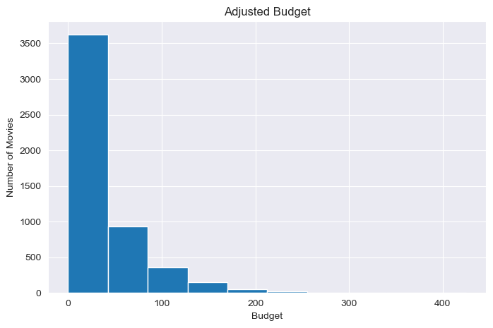

```python
# Histogram of adjusted budget
df['budget_adj ($Million)'].hist(figsize=(8,5))
plt.title('Adjusted Budget')
plt.xlabel('Budget')
plt.ylabel('Number of Movies');
```

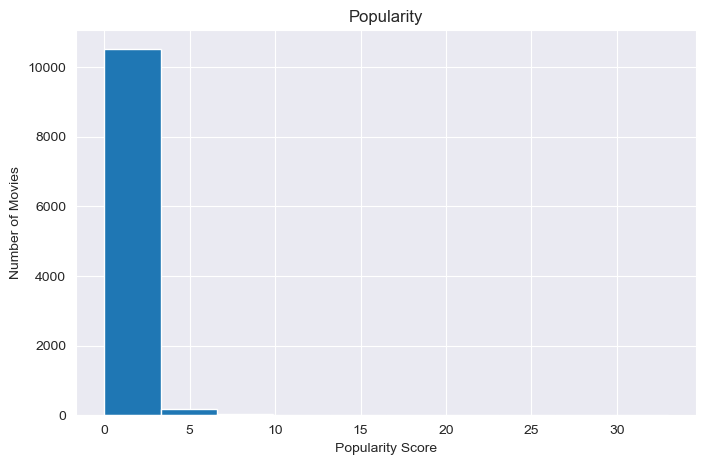

```python
# Histogram of popularity
df['popularity'].hist(figsize=(8,5))
plt.title('Popularity')
plt.xlabel('Popularity Score')
plt.ylabel('Number of Movies');
```

I made two histograms of budget and popularity, to give an overview. They look fairly similar by themselves, so I will compare them in another graph to get a better understading of the relationship between the two variables.

```python
# function for scatter plots
def scatterPlots(df, var1, var2):
    sns.lmplot(x=var1, y=var2, data=df)  # plot graph

    # clean up label names
    var1=var1.replace('_', ' ')
    var2=var2.replace('_', ' ')

    # add title & x, y labels
    plt.title(f'{var1} vs. {var2}'.title(), fontsize=12)
    plt.xlabel(var1.title())
    plt.ylabel(var2.title())
```

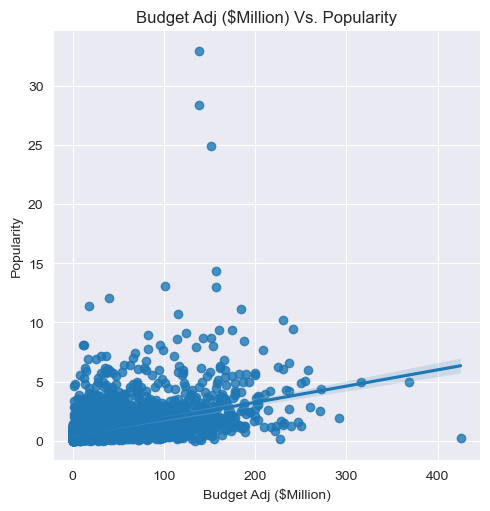

```python
# call scatter plot function
scatterPlots(df,'budget_adj ($Million)','popularity')
```

From this graph, it looks like having a higher budget may have a positive impact on popularity scores. However, the outliers seem to show that having a very high budget may not have a positive impact on popularity, as the most popular movies are in the mid-budget range.

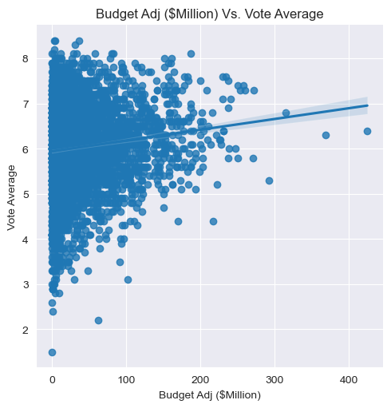

```python
# call scatter plot function
scatterPlots(df,'budget_adj ($Million)', 'vote_average')
```

### Does a higher budget mean a higher revenue?

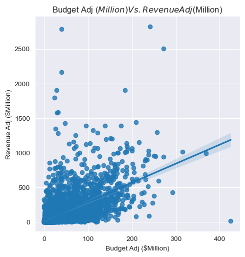

```python
# call scatter plot function
scatterPlots(df, 'budget_adj ($Million)', 'revenue_adj ($Million)')
```

This first scatterplot is showing the relationship between budget and revenue. It looks like a higher budget is associated with movies having a higher revenue as well. However, too high of a budget looks like it may result in losses.

```python
mean_budget = df['budget_adj ($Million)'] .mean()
mean_budget
```

```
36.99582173917226
```

```python
mean_revenue = df['revenue_adj ($Million)'] .mean()
mean_revenue
```

```
115.23412101716015
```

I want to compare the mean budget and revenue together, to see if maybe it can give more insight into the variables, and their relationship.

[figure not shown]

```python
locations = [1, 2]
heights = [mean_budget, mean_revenue]
labels = ['Budget', 'Revenue']
plt.bar(locations, heights, tick_label=labels)
plt.title('Mean Budget vs. Revenue (Adjusted)')
plt.ylabel('$ Hundred Million');
```

### What director has the most popularity ratings?

```python
# split values
df['director'] = df['director'].str.split('|')
director_split = df.explode('director')
```

I am splitting the director column, since there are multiple names in some of the rows that need to be separated.

```python
# Top directors based on movie counts
director_split['director'].value_counts().head()
```

```
director
Woody Allen          46
Clint Eastwood       34
Martin Scorsese      30
Steven Spielberg     30
Steven Soderbergh    23
Name: count, dtype: int64
```

This is an overview of the top directors.

```python
# top directors based on mean popularity
directors = director_split.groupby('director')['popularity'].mean().sort_values(ascending=False).head(100)
directors.head()
```

```
director
Colin Trevorrow    16.696886
Chad Stahelski     11.422751
David Leitch       11.422751
Juno John Lee       8.411577
Alan Taylor         6.883129
Name: popularity, dtype: float64
```

I checked what the top directors are based on mean popularity ratings, to get another viewpoint on the dataset. I did this because using the popularity catagory seems like the best way to determine the top director.

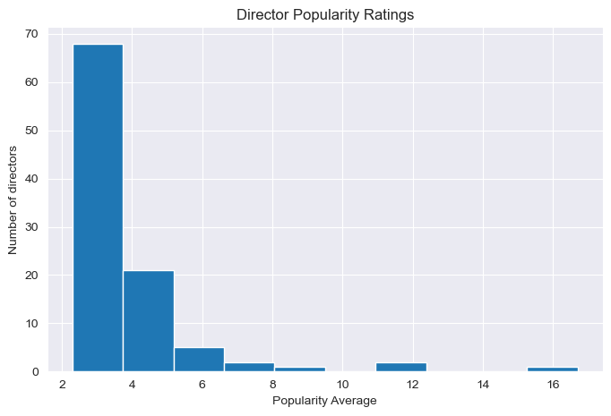

```python
# histogram of mean popularity of top directors
directors.hist(figsize=(8,5))
plt.title('Director Popularity Ratings')
plt.ylabel('Number of directors')
plt.xlabel('Popularity Average');
```

This histogram shows the grouping of the popularity ratings of the top 100 directors. It looks skewed right, with most ratings falling between 2 and 4. However, the popularity ranking system is not very clear since there are some high outliers.

### What genres are most popular?

```python
# split genres at seperator
df['genres'] = df['genres'].str.split('|')
genres_split = df.explode('genres')
```

I am separating the data in the Genre column, since there are multiple genres in each row.

```python
# get count of top genres
genres_split['genres'].value_counts()
```

```
genres
Drama              4746
Comedy             3775
Thriller           2902
Action             2376
Romance            1708
Horror             1636
Adventure          1465
Crime              1353
Science Fiction    1221
Family             1214
Fantasy             908
Mystery             808
Animation           664
Documentary         470
Music               399
History             330
War                 268
Foreign             184
Western             164
TV Movie            162
Name: count, dtype: int64
```

These are the value counts for top movie genres.

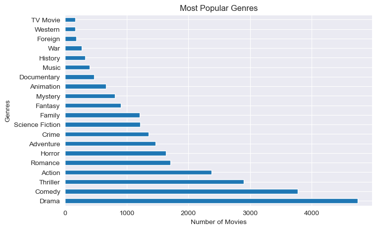

```python
# make genre graph for better visualization
genres_split['genres'].value_counts().plot(x='counts', kind='barh', figsize=(8,5))
plt.title('Most Popular Genres')
plt.xlabel('Number of Movies')
plt.ylabel('Genres');
```

It looks like the top 3 genres are Drama, Comedy, and Thriller. But these are just the most common movie genres, so next I want to check if these also have the highest vote count.

```python
# genres with highest audience vote
popular_genres = genres_split.groupby('genres')['vote_count'].mean().sort_values(ascending=False)
popular_genres.head()
```

```
genres
Adventure          515.130375
Science Fiction    439.832924
Fantasy            424.170705
Action             394.242424
Animation          317.146084
Name: vote_count, dtype: float64
```

I'm comparing genres to the vote count, to see which genres had the highest audience votes.

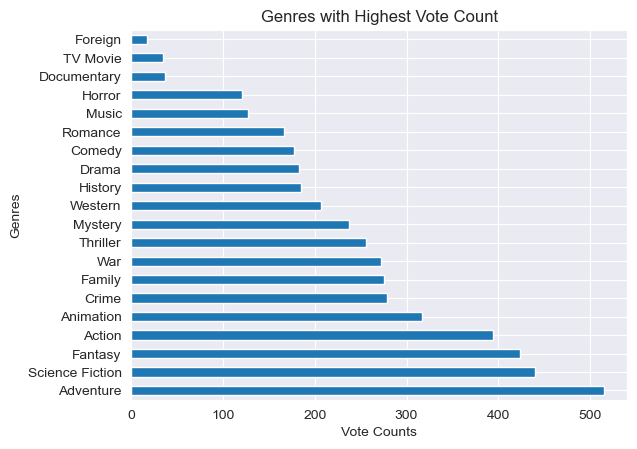

```python
popular_genres.plot.barh(x='genres', y='vote_count')
plt.title('Genres with Highest Vote Count')
plt.ylabel('Genres')
plt.xlabel('Vote Counts');
```

### Which actor is associated with highest popularity and revenue?

```python
cast_df.groupby('cast')[['popularity','revenue_adj']].sum().sort_values('revenue_adj',ascending=False).head(5)
```

| cast | popularity | revenue_adj |
| --- | --- | --- |
| Harrison Ford | 80.138138 | 1.468348e+10 |
| Tom Cruise | 59.140741 | 1.121280e+10 |
| Tom Hanks | 66.540270 | 1.067239e+10 |
| Emma Watson | 53.598217 | 8.806337e+09 |
| Ian McKellen | 61.067864 | 8.671323e+09 |

The top three actors associated with the highest revenue are Harrison Ford, Tom Cruise, and Tom Hanks. These popular actors are known to be in blockbuster films, but as popular actors and drectors often change, I will be looking at other factors that can be better related to movie success.

### What decade produced the highest revenue?

```python
# Get sum of movie revenue, grouped by decade
revenue_decades = df.groupby('decades')['revenue_adj ($Million)'].sum()
```

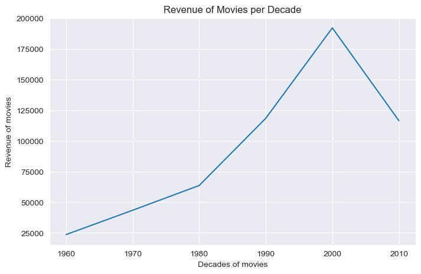

```python
# Line graph

plt.figure(figsize=(8,5))
plt.xlabel('Decades of movies')
plt.ylabel('Revenue of movies')
plt.title('Revenue of Movies per Decade')

plt.plot(revenue_decades)
plt.show()
```

```python
# double check decade
revenue_decades.idxmax()
```

```
'2000'
```

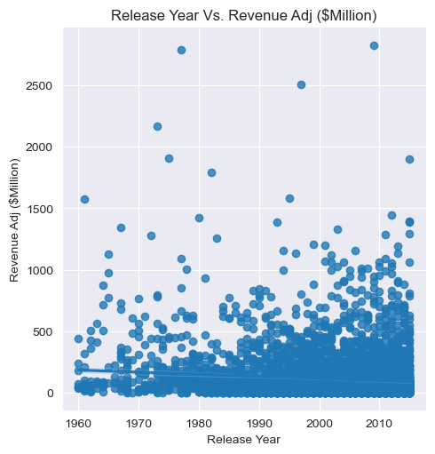

```python
# call scatter plot function
scatterPlots(df,'release_year', 'revenue_adj ($Million)')
```

I made a scatterplot to show the revenue in individial years instead of decades. I wanted to have a more detailed visual representation, since it looks like revenue has been increasing through the decades. However, the line of best fit shows a slight negative correlation. I will check this later, along with the correlation coefficient.

### Correlation Plots

These are some plots to further investigate any possible correlations between categories that I think are the most relevant to a films success.

```python
#information on top revenue films
movie_info = pd.DataFrame(df['revenue_adj ($Million)'].sort_values(ascending=False))
data_set = ['popularity','budget_adj ($Million)','release_year','original_title','cast','director','genres', 'runtime','vote_average','release_year']
for i in data_set:
    movie_info[i] = df[i]
movie_info.head(5)
```

|  | revenue_adj ($Million) | popularity | budget_adj ($Million) | release_year | original_title | cast | director | genres | runtime | vote_average |
| --- | --- | --- | --- | --- | --- | --- | --- | --- | --- | --- |
| 1386 | 2827.123750 | 9.432768 | 240.886903 | 2009 | Avatar | [Sam Worthington, Zoe Saldana, Sigourney Weave... | James Cameron | Action\|Adventure\|Fantasy\|Science Fiction | 162 | 7.1 |
| 1329 | 2789.712242 | 12.037933 | 39.575591 | 1977 | Star Wars | [Mark Hamill, Harrison Ford, Carrie Fisher, Pe... | George Lucas | Adventure\|Action\|Science Fiction | 121 | 7.9 |
| 5231 | 2506.405735 | 4.355219 | 271.692064 | 1997 | Titanic | [Kate Winslet, Leonardo DiCaprio, Frances Fish... | James Cameron | Drama\|Romance\|Thriller | 194 | 7.3 |
| 10594 | 2167.324901 | 2.010733 | 39.289277 | 1973 | The Exorcist | [Linda Blair, Max von Sydow, Ellen Burstyn, Ja... | William Friedkin | Drama\|Horror\|Thriller | 122 | 7.2 |
| 9806 | 1907.005842 | 2.563191 | 28.362748 | 1975 | Jaws | [Roy Scheider, Robert Shaw, Richard Dreyfuss, ... | Steven Spielberg | Horror\|Thriller\|Adventure | 124 | 7.3 |

```python
def plot_correlation(df):
    corr = df.corr()
    _ , ax = plt.subplots( figsize =( 10 , 8 ) )
    cmap = sns.diverging_palette( 240 , 10 , as_cmap = True )
    _ = sns.heatmap(corr,cmap = cmap,square=True, cbar_kws={ 'shrink' : .9 }, ax=ax, annot = True, annot_kws = { 'fontsize' : 12 })
```

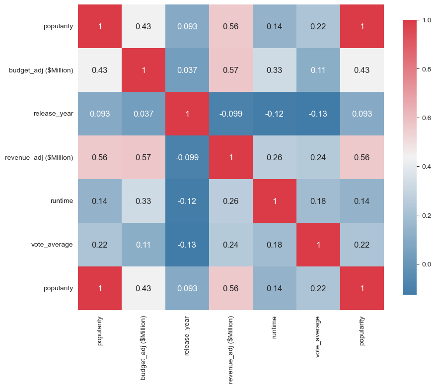

```python
#heatmap plot
plot_correlation(df[['popularity','budget_adj ($Million)','release_year','revenue_adj ($Million)','runtime','vote_average', 'popularity']])
```

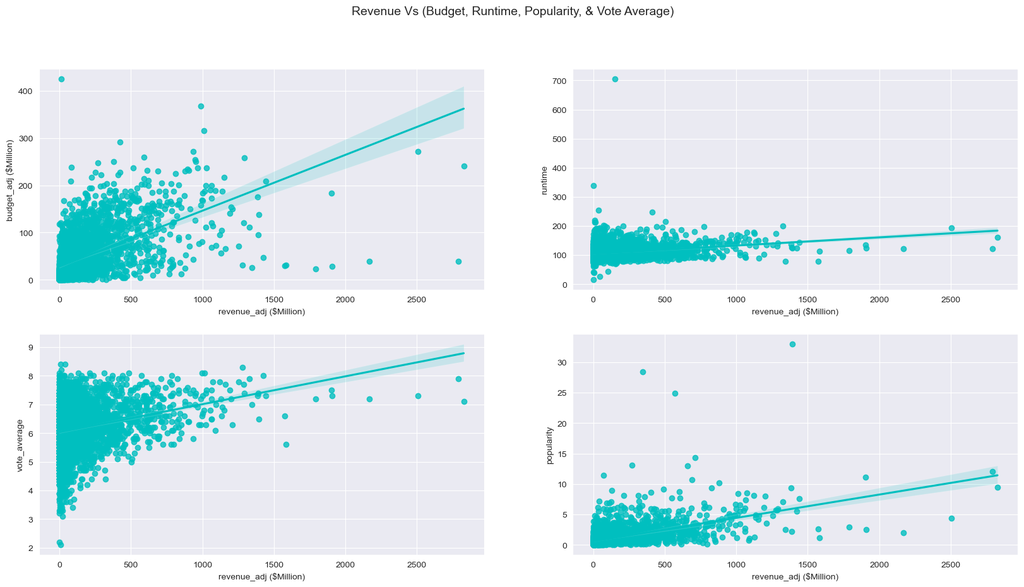

```python
# plot of revenue vs. buget, runtime, popularity, vote average
fig, axes = plt.subplots(2,2,figsize = (20,10))
fig.suptitle("Revenue Vs (Budget, Runtime, Popularity, & Vote Average)",fontsize=14)
sns.regplot(x=df['revenue_adj ($Million)'], y=df['budget_adj ($Million)'],color='c',ax=axes[0][0])
sns.regplot(x=df['revenue_adj ($Million)'], y=df['runtime'],color='c',ax=axes[0][1])
sns.regplot(x=df['revenue_adj ($Million)'], y=df['vote_average'],color='c',ax=axes[1][0])
sns.regplot(x=df['revenue_adj ($Million)'], y=df['popularity'],color='c',ax=axes[1][1])

sns.set_style("whitegrid")
```

*Revenue vs Budget:* The above plot shows that films with higher budgets have slightly higher revenues. There are few movies with very high budgets however, but there seems to be a moderate positive correlation with a coefficent value of 0.57.

*Revenue vs Runtime:* Revenue and runtime have a correlation coefficient of 0.26. This, along with the above plot, shows that runtime is not a significant factor in revenue.

*Revenue vs vote average:* The above graph shows a weak positive correlation revenue and vote average, and as the correlation coefficien is 0.24, there is not much influence between vote average and movie revenue.

*Revenue vs Popularity:* According to the above plot and heatmap, popularity does seem to have an influence on revenue as there is a moderate positive correlation and a coefficient of 0.56.

## Conclusions

#### Question 1: Are movies more popular if they have a higher budget?

> It looks like having a higher budget is associated with a movie being more popular. However, the outliers show that having too high of a budget can have the opposite effect, and a movie might even be less popular than average. It also looks like budget does not have a significant impact on a viewer ratings. As budget increases, it looks like the average ratings don't necessarily increase. However, there were many outliers in this dataset as well.

#### Question 2: Does a higher budget mean a higher revenue?

> In general, the majority of the data show that a higher budget means higher revenue for movies. However, there are outliers that show a high budget can mean revenue losses, or a low budget can bring high revenue as well.

#### Question 3: Who is the top director?

> The top director with the most movie counts is Woody Allen. However, I specifically wanted to know if the top director meant the most popular, so I got the mean popularity score of all directors. This time it showed Colin Trevorrow was the top director with the highest popularity average instead. However, the popularity scoring system is somewhat unclear since it is specific to TMDB.

#### Question 4: What genres are most popular?

> The top three genres overall are Drama, Comedy, and Thriller, which means those had the most releases. However, I wanted to know if those genres also had the highest audience votes, so I compared the genres to the mean vote count. This time, the data showed that the most popular genres in terms of vote count were actually Adventure, Science Fiction, and Fantasy.

#### Resources

- https://matplotlib.org/stable/users/index.html
- https://pandas.pydata.org/docs/user_guide/index.html
- https://seaborn.pydata.org/tutorial.html
- https://developer.themoviedb.org/docs/popularity-and-trending#popularity